# Analysis of Portland Jetport Historical Weather Data

# Introduction

This is a revision to draft R Notebooks preparing earlier versions of graphics. It includes only code used in the last round of design and redesign decisions. A more complete collection of draft graphics are in “max, min and averages.Rmd”

# Install Libraries

```r
library(tidyverse)
library(readr)
library(ggthemes)
library(svglite)

library(CBEPgraphics)
```

# Load Data

```r
sibfldnm <- 'Original Data'
parent <- dirname(getwd())
sibling <- paste(parent,sibfldnm, sep = '/')
fn <- 'longannualdata.csv'

longannualdata <- read_csv(paste(sibling, fn, sep = '/')) %>%
  select(-station) %>%
  mutate(year = as.numeric(format(date, format = '%Y'))) %>%
  mutate(cyear = year - 1980)
```

# Annual Minimum, Maximum and Average Temperature

Codes for key temperature records in the downloaded annual data are: TAVG – Annual Average Temperature (unweighted; effectively average of monthly averages, of daily maxes and mins. Note that this means this is not independent of the other two metrics.) EMXT – Extreme Maximum Annual Temperature EMNT – Extreme Minimum Temperature

```r
tdata <- longannualdata %>%
  filter(datatype %in% c('TAVG', 'EMXT', 'EMNT')) %>%
  mutate(value = value*(9/5)+32) %>%
  mutate(datatype = factor(datatype, levels = c('EMXT', 'TAVG', 'EMNT' )))
```

```r
tdata.centered <- longannualdata %>%
  filter(datatype %in% c('TAVG', 'EMXT', 'EMNT')) %>%
  mutate(value = value*(9/5)+32) %>%
  select(-attributes) %>%
  spread(key = datatype, value = value) %>%
  mutate_at(c('TAVG', 'EMXT', 'EMNT'), ~ scale(., scale = FALSE)) %>%
  gather(key = 'datatype', value = 'value', -date, -year, -cyear) %>%
  mutate(datatype = factor(datatype, levels = c('EMXT', 'TAVG', 'EMNT' )))
```

```
attributes are not identical across measure variables;
they will be dropped
```

```r
tdata.centered.wide <- tdata.centered %>%
  spread(key = datatype, value = value)

mean.lm.2 <- lm(TAVG ~ cyear, data = tdata.centered.wide)
min.lm.2  <- lm(EMNT ~ cyear, data = tdata.centered.wide)
max.lm.2  <- lm(EMXT ~ cyear, data = tdata.centered.wide)
```

## Create Labels

Note the way we assemble a mathematical expression to be interpreted by “plotmath” for the annotations. The key idea is that you need to link each symbol or word either with “~” if you want a space, or "*" if you don’t.

```r
labs <-  tibble(datatype = c("EMXT", "TAVG", "EMNT"),
              ypos1 = c(85, 55, 10),
              xpos = c(1950, 2000, 2000),
              txt = c("No~trend",
                       paste(round(mean.lm.2$coef[2]*10,2), '~degree*F', "~per~decade"),
                       paste(round(min.lm.2$coef[2]*10,2), '~degree*F', "~per~decade")) ) %>%
  mutate(datatype = factor(datatype, levels = c('EMXT', 'TAVG', 'EMNT' )))
```

## Temperature Plot

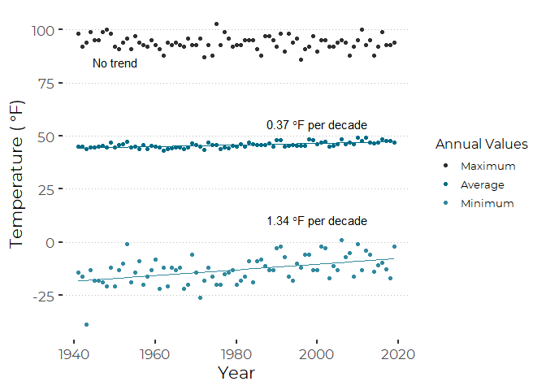

```r
plt <- ggplot(tdata, aes(year, value, color=datatype)) + geom_point() +
  geom_smooth(aes(lty = datatype), method = 'lm', formula = y~x, se = FALSE, lwd = 0.5) +

  xlab('Year') +
  ylab (expression('Temperature ('*~degree*F*')')) +

  scale_color_manual(values = cbep_colors2(),
                     name = 'Annual Values',
                     labels = c('Maximum', 'Average', 'Minimum')) +
  scale_linetype_manual(values=c("blank", "solid", "solid"),
                        name = 'Annual Values',
                        labels = c('Maximum', 'Average', 'Minimum')) +
  scale_y_continuous(breaks = seq(-25 , 100, 25)) +
  guides(color = guide_legend(override.aes = list(linetype = 0)))+

  theme_cbep() +
  theme(panel.grid.major.y = element_line(size = 0.5, color = 'gray', linetype = 3),
        legend.text = element_text(size = 10),
        legend.title = element_text(size = 12)) +
  annotate("text", x = labs$xpos, y = labs$ypos1, label = labs$txt, parse = TRUE)
plt
```

```r
ggsave('maxavgmin.pdf', device = cairo_pdf, width = 7,height = 5)
ggsave('maxavgmin.png', width = 7,height = 5, type ='cairo')
```

# Precipitation Totals

Codes for key annual PRECIPITATION records in the downloaded data are: PRCP: Total Monthly (Annual) precipitation. Precipitation totals are based on daily or multi-day (if daily is missing) precipitation report, in millimeters to tenths. SNOW: Total Monthly (Annual) Snowfall in millimeters.

## Read Data and Transform to English Units.

```r
pdata <- longannualdata %>%
  filter(datatype %in% c('PRCP', 'SNOW')) %>%
  mutate(datatype = factor(datatype)) %>%
  mutate(value = value * 0.0394) %>%
  spread(key = datatype, value = value)

precip.lm <- lm(PRCP ~ year, data = pdata)
```

## Precipitation Plot

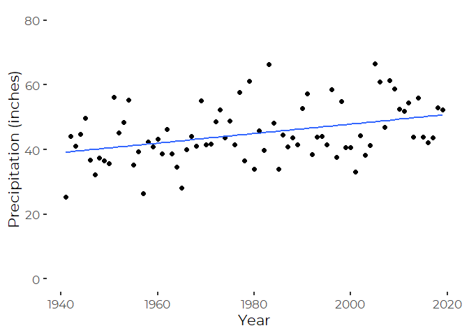

```r
plt <- ggplot(pdata, aes(year, PRCP)) +
  geom_point(size = 2) +
  geom_smooth(method='lm', se = FALSE, lty = 1) +
  xlab('Year') +
  ylab('Precipitation (inches)') +
  ylim(c(0, 80))  +
  theme_cbep()
plt
```

## Add Annotation and Save

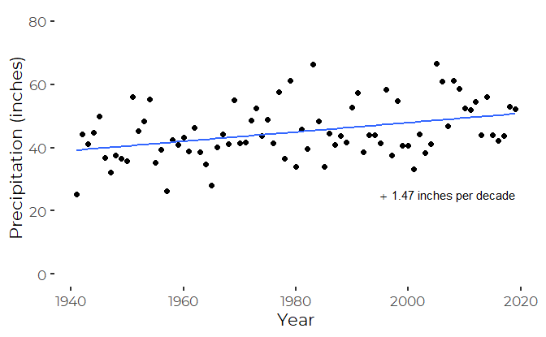

```r
txt <- paste('+~', round(precip.lm$coef[2]*10,2), '~inches', "~per~decade")
plt +
  annotate("text", x = 1995, y = 25, label = txt, parse = TRUE, hjust = 0, color = 'black')
```

```r
ggsave('precip.pdf', device = cairo_pdf, width = 7, height = 5)
ggsave('precip.png', width = 7, height = 5, type = 'cairo')
```